# Phishing URLs Detector

It is important to click on the right websites for the safety and security of the devices we are using. These devices hold so much information about us, what we do, etc; that it is essential to be mindful of phishing URLs. Thus, the goal of this project is to be able to detect whether a URL can be phishing or legitimate.

This project will attempt to solve the issue of phishing URLs and build a model that can detect the origin of the URL for cybersafety and prevent malicious activity from accessing our devices and information. The main questions to be answered are:

- What conditions can have a high impact into predicting if a link is a phishing link?
- What parts of the URL does not help to discover a phishing link?
- How accurate can a model be to discover a phishing link?
- Does the model generate a lot of false negatives?
- Is only the URL format enough to detect a phishing link? Would we need more information about the URL? such as domain, subdomains, etc.

### Dataset

I am working with a dataset from Kaggle that contains over 2 million rows (2GB) of examples of malicious and legitimate urls. dataset: https://www.kaggle.com/datasets/sergioagudelo/phishing-url-detection

#### Key Features

There are more features involved to this dataset. However, these following will be the features that I will be using to train and test the model and answer the previous questions

- Label - labels a link as legitimate or phishing - str (two unique values)
- url_length - float
- starts_with_ip - boolean
- url_entropy - url uncertainty - float
- has_punycode - boolean
- digit_letter_ratio - float
- dot_count - int
- at_count - int
- dash_count - int
- tld_count - int
- domain_has_digits - boolean
- subdomain_count - int
- nan_char_entropy - number character uncertainty - float
- has_internal_links - boolean

### Personal Goal

I will be using different components that form a url (such as the dot count, the length of the URL, the domain/subdomains, etc; to, then, train a pre-built model and test the accuracy, recall, etc. My personal goal to get the model to be as accurate as possible. I will be testing with multiple algorithms and test which one adapts to the data and is better at predicting correctly with this type of data.

## Pre-Processing

In this step, I will be cleaning the dataset a bit more to make sure that it is ready for visualizations and model usage. The dataset is sort of clean already and the components of the URLs are already broken down into relevant information that would help to find a pattern

```python
import pandas as pd
import numpy as np
import matplotlib.pyplot as plt
import seaborn as sns
```

```python
data = pd.read_csv('dataset/out.csv')
```

```python
df = pd.DataFrame(data)
```

```python
df.head()
```

|  | url | source | label | url_length | starts_with_ip | url_entropy | has_punycode | digit_letter_ratio | dot_count | at_count | dash_count | tld_count | domain_has_digits | subdomain_count | nan_char_entropy | has_internal_links | whois_data | domain_age_days |
| --- | --- | --- | --- | --- | --- | --- | --- | --- | --- | --- | --- | --- | --- | --- | --- | --- | --- | --- |
| 0 | apaceast.cloudguest.central.arubanetworks.com | Cisco-Umbrella | legitimate | 45 | False | 3.924535 | False | 0.0 | 4 | 0 | 0 | 0 | False | 3 | 0.310387 | False | {'domain_name': ['ARUBANETWORKS.COM', 'arubane... | 8250.0 |
| 1 | quintadonoval.com | Majestic | legitimate | 17 | False | 3.572469 | False | 0.0 | 1 | 0 | 0 | 0 | False | 0 | 0.240439 | False | {'domain_name': ['QUINTADONOVAL.COM', 'quintad... | 10106.0 |
| 2 | nomadfactory.com | Majestic | legitimate | 16 | False | 3.327820 | False | 0.0 | 1 | 0 | 0 | 0 | False | 0 | 0.250000 | False | {'domain_name': ['NOMADFACTORY.COM', 'nomadfac... | 8111.0 |
| 3 | tvarenasport.com | Majestic | legitimate | 16 | False | 3.500000 | False | 0.0 | 1 | 0 | 0 | 0 | False | 0 | 0.250000 | False | {'domain_name': ['TVARENASPORT.COM', 'tvarenas... | 5542.0 |
| 4 | widget.cluster.groovehq.com | Cisco-Umbrella | legitimate | 27 | False | 3.930270 | False | 0.0 | 3 | 0 | 0 | 0 | False | 2 | 0.352214 | False | {'domain_name': 'GROOVEHQ.COM', 'registrar': '... | 5098.0 |

```python
df.dtypes
```

```
url                    object
source                 object
label                  object
url_length              int64
starts_with_ip           bool
url_entropy           float64
has_punycode             bool
digit_letter_ratio    float64
dot_count               int64
at_count                int64
dash_count              int64
tld_count               int64
domain_has_digits        bool
subdomain_count         int64
nan_char_entropy      float64
has_internal_links       bool
whois_data             object
domain_age_days       float64
dtype: object
```

```python
# Conversion of data type to numerical values and smaller space
for col in df.columns:
    if df[col].dtype == bool:
        df[col] = df[col].astype('int32')

    elif df[col].dtype == float:
        df[col] = df[col].astype('float32')
```

```python
df.dtypes
```

```
url                    object
source                 object
label                  object
url_length              int64
starts_with_ip          int32
url_entropy           float32
has_punycode            int32
digit_letter_ratio    float32
dot_count               int64
at_count                int64
dash_count              int64
tld_count               int64
domain_has_digits       int32
subdomain_count         int64
nan_char_entropy      float32
has_internal_links      int32
whois_data             object
domain_age_days       float32
dtype: object
```

After taking a look at the dataset and the values I am working with, I want to start working on fixing missing values and dropping, what I think can be, irrelevant columns for the goal of the project.

```python
df.isna().sum()
```

```
url                        1
source                     0
label                      0
url_length                 0
starts_with_ip             0
url_entropy                0
has_punycode               0
digit_letter_ratio         1
dot_count                  0
at_count                   0
dash_count                 0
tld_count                  0
domain_has_digits          0
subdomain_count            0
nan_char_entropy           0
has_internal_links         0
whois_data            545300
domain_age_days       750689
dtype: int64
```

```python
# Drop the null value rows based on the url column
df = df.dropna(subset='url')
df.isna().sum()
```

```
url                        0
source                     0
label                      0
url_length                 0
starts_with_ip             0
url_entropy                0
has_punycode               0
digit_letter_ratio         0
dot_count                  0
at_count                   0
dash_count                 0
tld_count                  0
domain_has_digits          0
subdomain_count            0
nan_char_entropy           0
has_internal_links         0
whois_data            545299
domain_age_days       750688
dtype: int64
```

```python
# drop columns with lots of null values and reset index
df = df.drop(columns=['source', 'whois_data', 'domain_age_days'])
df.reset_index(drop=True, inplace=True)
```

There were a lot of missing values for the previous two columns. Therefore, I thought they might not help us determine whether or not a url is legitimate in this case. I also decided to get rid of the urls themselves since they will not help determining the url label (the important information about the url is already broken down)

```python
# Drop the column url and saves it in urls variable
urls = df.pop('url')
```

```python
df.head()
```

|  | label | url_length | starts_with_ip | url_entropy | has_punycode | digit_letter_ratio | dot_count | at_count | dash_count | tld_count | domain_has_digits | subdomain_count | nan_char_entropy | has_internal_links |
| --- | --- | --- | --- | --- | --- | --- | --- | --- | --- | --- | --- | --- | --- | --- |
| 0 | legitimate | 45 | 0 | 3.924535 | 0 | 0.0 | 4 | 0 | 0 | 0 | 0 | 3 | 0.310387 | 0 |
| 1 | legitimate | 17 | 0 | 3.572469 | 0 | 0.0 | 1 | 0 | 0 | 0 | 0 | 0 | 0.240439 | 0 |
| 2 | legitimate | 16 | 0 | 3.327820 | 0 | 0.0 | 1 | 0 | 0 | 0 | 0 | 0 | 0.250000 | 0 |
| 3 | legitimate | 16 | 0 | 3.500000 | 0 | 0.0 | 1 | 0 | 0 | 0 | 0 | 0 | 0.250000 | 0 |
| 4 | legitimate | 27 | 0 | 3.930270 | 0 | 0.0 | 3 | 0 | 0 | 0 | 0 | 2 | 0.352214 | 0 |

```python
df.isna().sum()
```

```
label                 0
url_length            0
starts_with_ip        0
url_entropy           0
has_punycode          0
digit_letter_ratio    0
dot_count             0
at_count              0
dash_count            0
tld_count             0
domain_has_digits     0
subdomain_count       0
nan_char_entropy      0
has_internal_links    0
dtype: int64
```

I will also use get dummies to categorize is a url is malicious or not using 1s for 'it is a phishing url' and 0s for 'it is legitimate'

```python
# convert the column 'label' into two columns with 1s and 0s
# representing the two unique values
df = pd.get_dummies(df, columns=['label'], dtype=int)
df
```

|  | url_length | starts_with_ip | url_entropy | has_punycode | digit_letter_ratio | dot_count | at_count | dash_count | tld_count | domain_has_digits | subdomain_count | nan_char_entropy | has_internal_links | label_legitimate | label_phishing |
| --- | --- | --- | --- | --- | --- | --- | --- | --- | --- | --- | --- | --- | --- | --- | --- |
| 0 | 45 | 0 | 3.924535 | 0 | 0.000000 | 4 | 0 | 0 | 0 | 0 | 3 | 0.310387 | 0 | 1 | 0 |
| 1 | 17 | 0 | 3.572469 | 0 | 0.000000 | 1 | 0 | 0 | 0 | 0 | 0 | 0.240439 | 0 | 1 | 0 |
| 2 | 16 | 0 | 3.327820 | 0 | 0.000000 | 1 | 0 | 0 | 0 | 0 | 0 | 0.250000 | 0 | 1 | 0 |
| 3 | 16 | 0 | 3.500000 | 0 | 0.000000 | 1 | 0 | 0 | 0 | 0 | 0 | 0.250000 | 0 | 1 | 0 |
| 4 | 27 | 0 | 3.930270 | 0 | 0.000000 | 3 | 0 | 0 | 0 | 0 | 2 | 0.352214 | 0 | 1 | 0 |
| ... | ... | ... | ... | ... | ... | ... | ... | ... | ... | ... | ... | ... | ... | ... | ... |
| 2499994 | 48 | 0 | 4.068902 | 0 | 0.000000 | 2 | 0 | 0 | 0 | 0 | 1 | 0.557393 | 0 | 0 | 1 |
| 2499995 | 41 | 0 | 4.257079 | 0 | 0.060606 | 2 | 0 | 1 | 0 | 0 | 1 | 0.555799 | 0 | 0 | 1 |
| 2499996 | 66 | 0 | 4.393365 | 0 | 0.000000 | 2 | 0 | 0 | 0 | 0 | 1 | 0.581139 | 0 | 0 | 1 |
| 2499997 | 102 | 0 | 4.763413 | 0 | 0.194444 | 3 | 0 | 0 | 0 | 0 | 0 | 0.787769 | 0 | 0 | 1 |
| 2499998 | 50 | 0 | 4.553270 | 0 | 0.102564 | 3 | 0 | 0 | 0 | 0 | 1 | 0.599944 | 0 | 0 | 1 |

2499999 rows × 15 columns

```python
df = df.drop(columns=['label_legitimate'])
df
```

|  | url_length | starts_with_ip | url_entropy | has_punycode | digit_letter_ratio | dot_count | at_count | dash_count | tld_count | domain_has_digits | subdomain_count | nan_char_entropy | has_internal_links | label_phishing |
| --- | --- | --- | --- | --- | --- | --- | --- | --- | --- | --- | --- | --- | --- | --- |
| 0 | 45 | 0 | 3.924535 | 0 | 0.000000 | 4 | 0 | 0 | 0 | 0 | 3 | 0.310387 | 0 | 0 |
| 1 | 17 | 0 | 3.572469 | 0 | 0.000000 | 1 | 0 | 0 | 0 | 0 | 0 | 0.240439 | 0 | 0 |
| 2 | 16 | 0 | 3.327820 | 0 | 0.000000 | 1 | 0 | 0 | 0 | 0 | 0 | 0.250000 | 0 | 0 |
| 3 | 16 | 0 | 3.500000 | 0 | 0.000000 | 1 | 0 | 0 | 0 | 0 | 0 | 0.250000 | 0 | 0 |
| 4 | 27 | 0 | 3.930270 | 0 | 0.000000 | 3 | 0 | 0 | 0 | 0 | 2 | 0.352214 | 0 | 0 |
| ... | ... | ... | ... | ... | ... | ... | ... | ... | ... | ... | ... | ... | ... | ... |
| 2499994 | 48 | 0 | 4.068902 | 0 | 0.000000 | 2 | 0 | 0 | 0 | 0 | 1 | 0.557393 | 0 | 1 |
| 2499995 | 41 | 0 | 4.257079 | 0 | 0.060606 | 2 | 0 | 1 | 0 | 0 | 1 | 0.555799 | 0 | 1 |
| 2499996 | 66 | 0 | 4.393365 | 0 | 0.000000 | 2 | 0 | 0 | 0 | 0 | 1 | 0.581139 | 0 | 1 |
| 2499997 | 102 | 0 | 4.763413 | 0 | 0.194444 | 3 | 0 | 0 | 0 | 0 | 0 | 0.787769 | 0 | 1 |
| 2499998 | 50 | 0 | 4.553270 | 0 | 0.102564 | 3 | 0 | 0 | 0 | 0 | 1 | 0.599944 | 0 | 1 |

2499999 rows × 14 columns

## Visualizations

Now that there is no longer null values and columns that can affect the model negatively, I will be starting to display some plots to be able to visualize any trends and understand the relationship of the data. Since this is somehwat a mdeium-large data frame, I decided to split it up into samples to make it easier to work with.

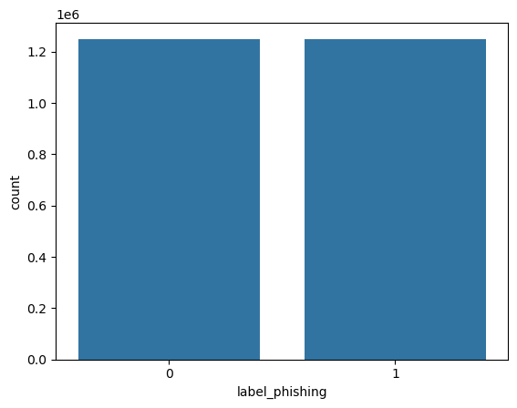

```python
# Count graph to visualize how balance the data target is
sns.countplot(df, x='label_phishing')
```

Based on the visual above, we have a very balanced dataset between phishing urls (being 1) and legitimate urls (being 0)

```python
sample_df = df.sample(frac=0.1, random_state=1)
sample_df.shape
```

```
(250000, 14)
```

I am selecting a random sample data frame to work with for easier plotting and visualizations to understand the data trends

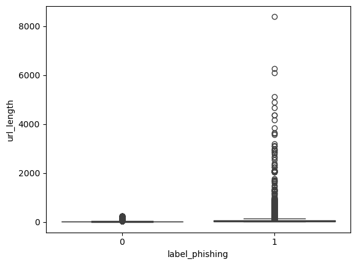

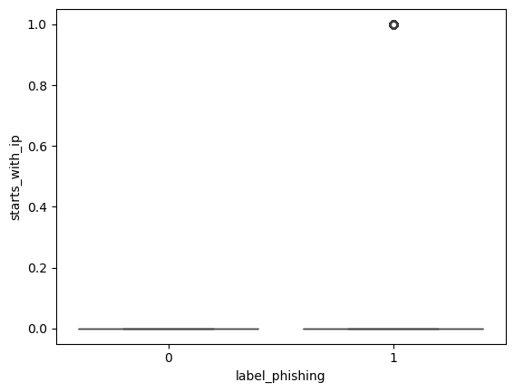

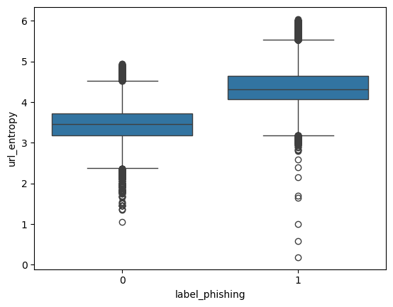

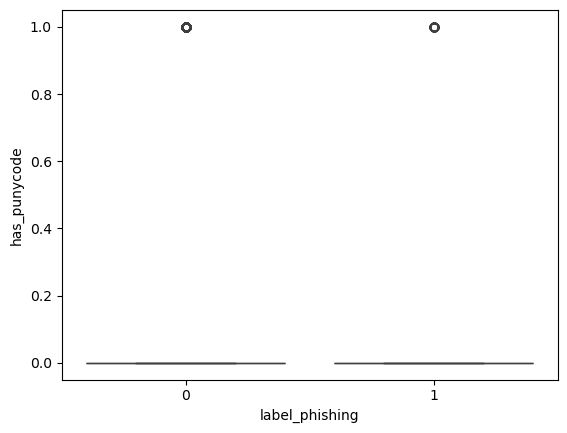

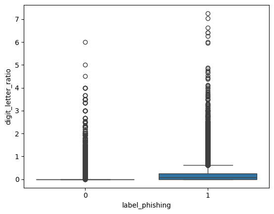

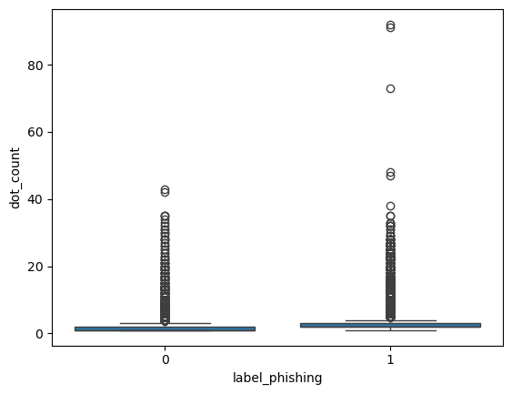

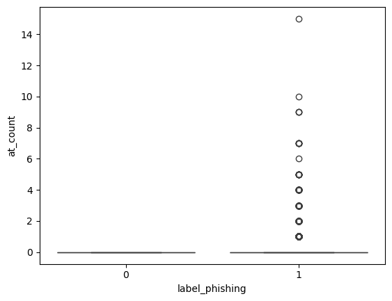

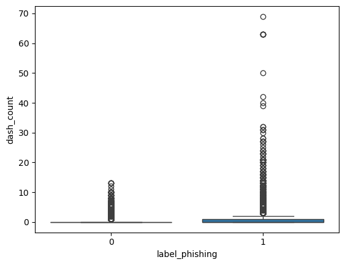

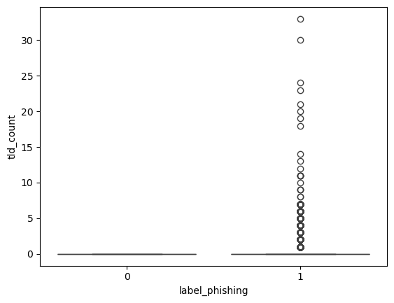

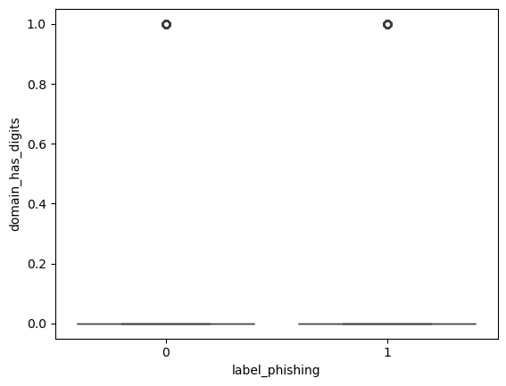

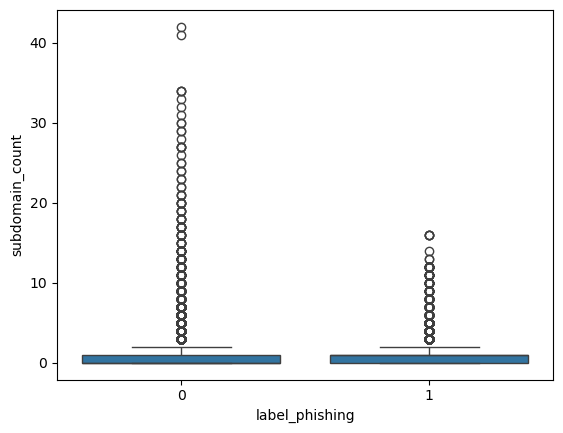

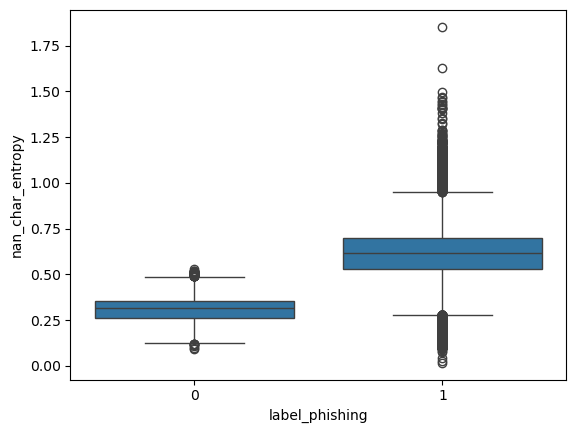

[1 more figures not shown]

```python
# Plot target agaisnt various features to evaluate relationship and outliers
for col in sample_df.columns:
    if col != 'label_phishing':
        sns.boxplot(data=sample_df, x='label_phishing', y=col)
        plt.show()
```

Afer these visuals, we are able to understand the data a bit better. I can see how some of the columns hold such as minuscule significance such as 'has_internal_links', 'domain_has_digits', 'has_punycode', 'starts_with_ip'. etc. Thus, I will be dropping those.

```python
df = df.drop(['has_internal_links', 'has_punycode', 'starts_with_ip', 'domain_has_digits'], axis=1)
```

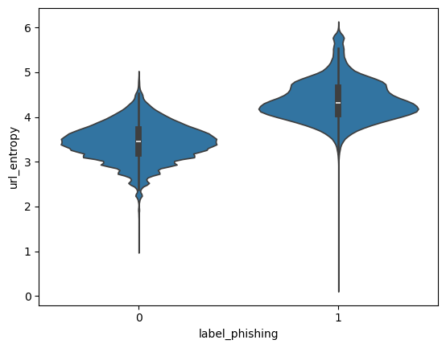

```python
sns.violinplot(data=sample_df, x='label_phishing', y='url_entropy', orient='v')
plt.show()
```

## Modeling (testing and learning)

For this project, I am thinking of using Random Forest, Logistic regression, or SVM and analyze which one works better with teh data. The reason why of using these is because they seem to work good with large datasets and some of them will give the data the ability to prevent overfitting (like random forest). All of them have their pros and cons but my top 2 are Random forest - works great with large datasets and prevents overfitting, Logistic regression - it is fast and simplicit

```python
from sklearn.ensemble import RandomForestClassifier
from sklearn.linear_model import LogisticRegression, SGDClassifier
from sklearn.svm import LinearSVC
from time import time
```

```python
# X will be our features and y is the target
X = df.drop(['label_phishing'], axis=1)
y = df['label_phishing']
```

```python
X.shape, y.shape
```

[output not shown]

```python
from sklearn.model_selection import train_test_split, cross_val_score
from sklearn.metrics import accuracy_score, precision_score, recall_score, f1_score, confusion_matrix, ConfusionMatrixDisplay
```

```python
# train test split for training and testing purposes
X_train, X_test, y_train, y_test = train_test_split(X, y, test_size=0.20, random_state=42)
```

```python
X_train.shape, y_train.shape
```

[output not shown]

Now that the data got split up, I will be also doing cross validation with the training set to understand which one is better for the model to be trained on

For testing and experimenting purposes, I will be using a total of 5 models. Two of those will be just stochastic gradient descent for logistic regression and SVM selecting the lowest amount of error. The other tree will be logistic regression itself, SVM itself, and random forest

```python
# Initializing models
models = {
    'random forest': RandomForestClassifier(),
    'SVC': LinearSVC(dual='auto'),
    'SGDC SVC': SGDClassifier(loss='hinge'),
    'SGDC LR' : SGDClassifier(loss='log_loss'),
    'logistic regression': LogisticRegression(solver='saga')
    }
```

I decided to directly train the model with the data instead of using cross validation because of the amount of data. Thus, the larger the dataset is, the more the need for CV minishes. It takes a time to train and test the models. It is definately better to split the data into batches for faster training time.

```python
# Iterates through the models and gets time for experimenting purposes
for name, model in models.items():
    print(f'This is model: {name}')
    start_time = time()
    model.fit(X_train, y_train)
    print(f'Time taken to train model: {round((time() - start_time), 2)}')

    # test and analyze accuracy
    y_pred = model.predict(X_test)

    # score accuracy score
    print('Accuracy score:')
    print(accuracy_score(y_test, y_pred))

    #print(f'Accuracy score for {name} : {}')
    print(f'Time taken to test and check accuracy: {round((time() - start_time), 2)}')
```

```
This is model: random forest
Time taken to train model: 261.98
Accuracy score:
0.999996
Time taken to test and check accuracy: 264.35
This is model: SVC
Time taken to train model: 6.57
Accuracy score:
0.999876
Time taken to test and check accuracy: 6.62
This is model: SGDC SVC
Time taken to train model: 21.44
Accuracy score:
0.978272
Time taken to test and check accuracy: 21.5
This is model: SGDC LR
Time taken to train model: 25.6
Accuracy score:
0.97904
Time taken to test and check accuracy: 25.65
This is model: logistic regression
Time taken to train model: 96.01
Accuracy score:
0.865544
Time taken to test and check accuracy: 96.07
```

Something that Logistic regression is good for, though, is determining the importance of the columns because it does not assume that the data points are independent. Thus, we can use this to adjust paramenters and get rid of data that is not important

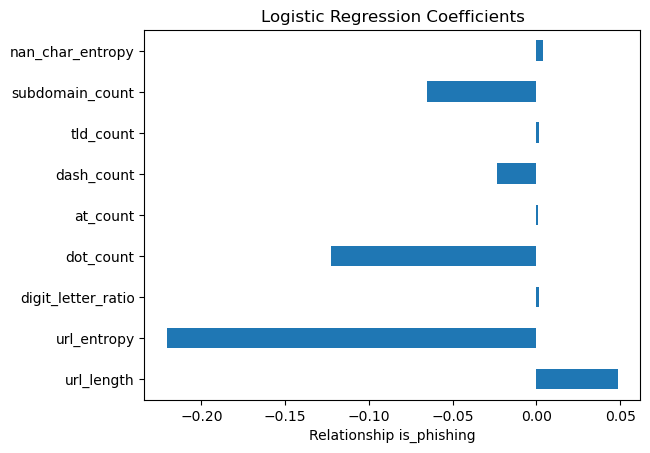

```python
coefficients = pd.DataFrame(models['logistic regression'].coef_, columns=X_train.columns)
coefficients.T.plot(kind='barh', legend=False)
plt.xlabel('Relationship is_phishing')
plt.title('Logistic Regression Coefficients')
plt.show()
```

```python
df = df.drop(columns=['tld_count', 'at_count', 'digit_letter_ratio'])
```

## Modeling (with Random Forest and SVC)

```python
model_fr = models['random forest']
model_svc = models['SVC']
```

```python
X = df.drop(['label_phishing'], axis=1)
y = df['label_phishing']
```

```python
# train test split
X_train, X_test, y_train, y_test = train_test_split(X, y, test_size=0.20, random_state=42)
```

```python
# train model
model_fr.fit(X_train, y_train)

# test and analyze accuracy
y_pred = model_fr.predict(X_test)

# score accuracy score
print('Accuracy score:')
accuracy_score(y_test, y_pred)
```

```
Accuracy score:
```

```
0.999998
```

```python
# train model
model_svc.fit(X_train, y_train)

# test and analyze accuracy
y_pred = model_svc.predict(X_test)

# score accuracy score
print('Accuracy score:')
accuracy_score(y_test, y_pred)
```

```
Accuracy score:
```

```
0.999896
```

Based on this information now, Random forest seems to be more accurate but it is not good to only based the accuracy of a model based on that score so I will be suing the confusion matrix, the f1, and recall scores

[figure not shown]

```python
ConfusionMatrixDisplay.from_predictions(y_test, y_pred)
plt.show()
```

```python
recall = recall_score(y_test, y_pred)
recall
```

```
0.9999960050655768
```

```python
f1 = f1_score(y_test, y_pred)
f1
```

```
0.9999980025287986
```

# Conclusion

I believe this is a good way to implement a classification model so that we can make safer places with analyzing whether a link is malicious or not. Although it might be dangerous to get a false negative, it is still not as harmful to humans like other integration of models can be. Thus, I think implementing a predictive measurement plus the proper training can be crucial for companies, etc.

#### Parts of the data that does not contribute

I was able to find there was some insightful but inrelevant data for predicting the URL models and training the model as well. One of the columns that where not benefitial to training the model or it would make the model not learn from the different characteristics but selecting (for example) there the data came from. For instance, the column 'source' had information of where the url came from (most legitimate and physhing urls came from the same place) Thus, that would have worked as a cheatsheet for the model.

#### Are there a lot of false negatives?

No, there was only one found

#### Is the format of the URL enough to detect the phishing url?

I do think that it can definitely help determine if a link is malicious or not. However, they might still make some mistakes. I would still implement a model like this so same time and lower risks

### About the model

random forest work the best for this time of classiffication. It was also the one that took the longest to train but the most accurate as well.